# Final

Ali Ozan Memetoğlu

4/2/2021

# Hourly Solar Power Plant Analysis

## Introduction

The main objective of this study is to forecast 2 day ahead hourly production by forecasting with time series analysis and regression. Both methods will be compared on a test set of the last day. MAPE is chosen as a performance metric.

Due to the nature of the solar production data, it is quite hard to make forecasting when you have zero values at the night time. Therefore since we are building our models on a specific hour level for a day, it was obligatory to make some filtering and examination at first. What is more, since we have many zero values and MAPE is considered as a performance metric, we could not include those night times when the production is zero when the performance is obtained.

The solar power production data set is provided by https://www.solarian.com.tr/referanslarimiz/cingilli-ges-nigde/. It mainly consists of TEMP, DSWRF, CLOUD_LOW_LAYER of four different coordinates and production in KWH in an hourly level from 2019-10-09 up to 2021-02-02.

## Manipulations and Some Initial Analysis

```r
require(data.table)
require(lubridate)
require(ggplot2)
require(urca)
require(stats)
require(forecast)

setwd('C:/Users/alioz/Downloads')
df = fread('production_data_with_weather.csv')
colnames(df)
```

```
##  [1] "Date"                        "Hour"
##  [3] "Production"                  "timestamp"
##  [5] "CLOUD_LOW_LAYER_37.75_34.25" "CLOUD_LOW_LAYER_37.75_34.5"
##  [7] "CLOUD_LOW_LAYER_38_34.25"    "CLOUD_LOW_LAYER_38_34.5"
##  [9] "DSWRF_37.75_34.25"           "DSWRF_37.75_34.5"
## [11] "DSWRF_38_34.25"              "DSWRF_38_34.5"
## [13] "TEMP_37.75_34.25"            "TEMP_37.75_34.5"
## [15] "TEMP_38_34.25"               "TEMP_38_34.5"
```

```r
str(df)
```

```
## Classes 'data.table' and 'data.frame':   11592 obs. of  16 variables:
##  $ Date                       : chr  "2019-10-09" "2019-10-09" "2019-10-09" "2019-10-09" ...
##  $ Hour                       : int  0 1 2 3 4 5 6 7 8 9 ...
##  $ Production                 : num  0 0 0 0 0 ...
##  $ timestamp                  : chr  "2019-10-09T00:00:00Z" "2019-10-09T01:00:00Z" "2019-10-09T02:00:00Z" "2019-10-09T03:00:00Z" ...
##  $ CLOUD_LOW_LAYER_37.75_34.25: int  0 0 0 0 0 0 0 0 0 0 ...
##  $ CLOUD_LOW_LAYER_37.75_34.5 : int  0 0 0 0 0 0 0 0 0 0 ...
##  $ CLOUD_LOW_LAYER_38_34.25   : int  0 0 0 0 0 0 0 0 0 0 ...
##  $ CLOUD_LOW_LAYER_38_34.5    : int  0 0 0 0 0 0 0 0 0 0 ...
##  $ DSWRF_37.75_34.25          : int  0 0 0 0 0 0 0 0 20 62 ...
##  $ DSWRF_37.75_34.5           : int  0 0 0 0 0 0 0 0 20 63 ...
##  $ DSWRF_38_34.25             : int  0 0 0 0 0 0 0 0 20 62 ...
##  $ DSWRF_38_34.5              : int  0 0 0 0 0 0 0 0 20 64 ...
##  $ TEMP_37.75_34.25           : num  17.1 16.9 15.9 15.1 14.9 ...
##  $ TEMP_37.75_34.5            : num  16.4 15.7 14.6 13.8 13.5 ...
##  $ TEMP_38_34.25              : num  14.5 14 13.5 12.9 12.6 ...
##  $ TEMP_38_34.5               : num  12.4 11.9 11.4 11.1 11.2 ...
##  - attr(*, ".internal.selfref")=<externalptr>
```

```r
df[,Date := as.Date(timestamp)]
df[,timestamp := as_datetime(timestamp)]

accu = function(actual, forecast){
  n = length(actual)
  error = actual - forecast
  mean = mean(actual)
  sd = sd(actual)
  FBias = sum(error)/sum(actual)
  MPE = sum(error/actual)/n
  MAPE = sum(abs(error/actual))/n
  RMSE = sqrt(sum(error^2)/n)
  MAD = sum(abs(error))/n
  WMAPE = MAD/mean
  return(data.frame(n,sd,FBias,MPE,MAPE,RMSE,MAD,WMAPE))
}
```

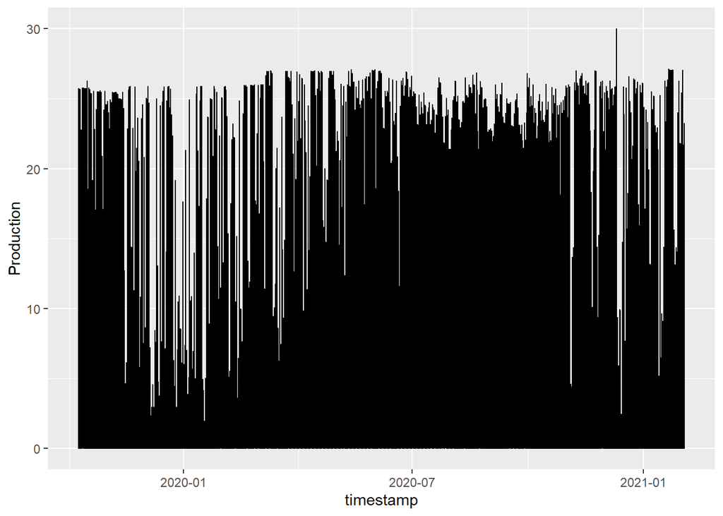

```r
ggplot(data = df, aes(x = timestamp, y = Production)) + geom_line()
```

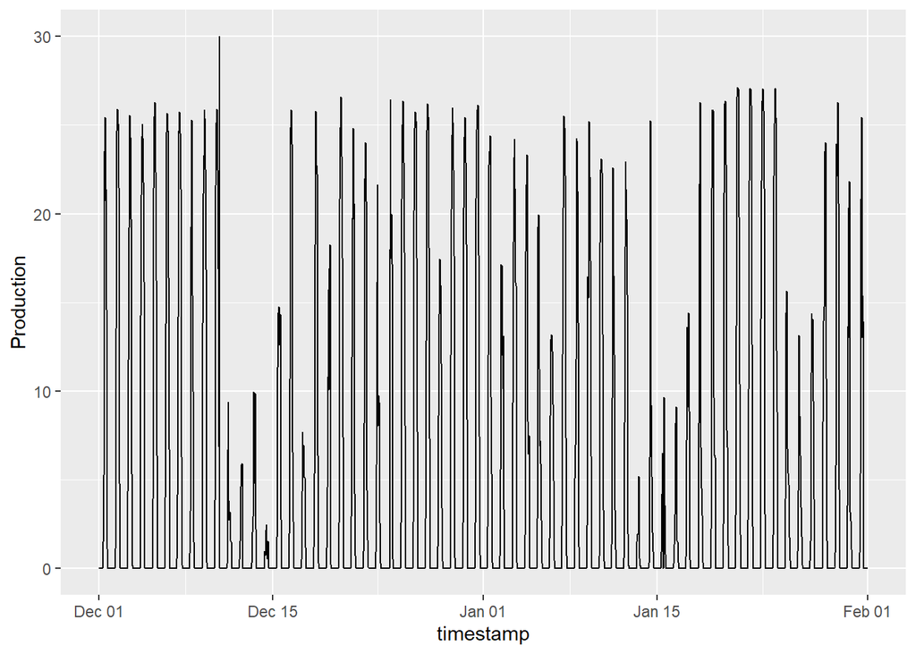

```r
ggplot(data = df[Date >= ymd(20201201) &
         Date < ymd(20210201)], aes(x = timestamp, y = Production)) + geom_line()
```

When we plot the data for the two months we can cleary observe zero production during night times. Although we can see a monthly seasonality in the two month plot (generaly high levels and an apparent decrease in the middle of the month), the production series does not show a stationary behavior since its mean and variance is changing. We could also observe this fact by calculating the variance and mean for different windows.

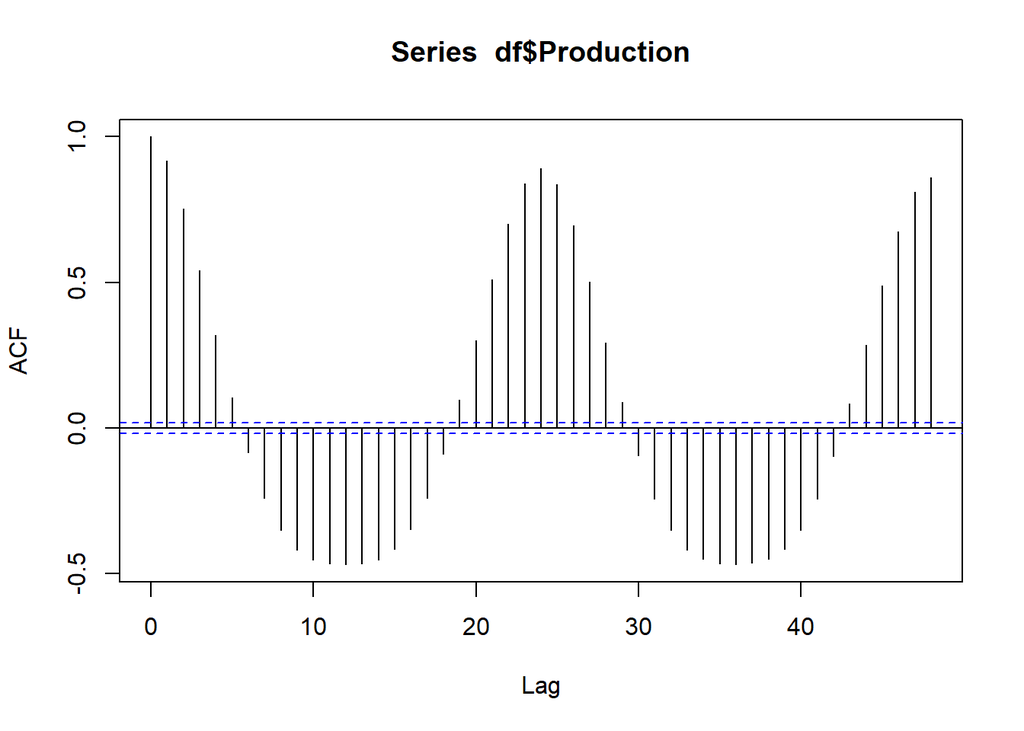

```r
acf(df$Production, lag.max = 48)
```

High correlations in lag 24 and 48 can be seen due to the nature of the data consisting of hourly solar energy productions.

```r
df[Date == as.Date('2021-02-02')]
```

```
##           Date Hour Production           timestamp CLOUD_LOW_LAYER_37.75_34.25
##  1: 2021-02-02    0       0.00 2021-02-02 00:00:00                           0
##  2: 2021-02-02    1       0.00 2021-02-02 01:00:00                           0
##  3: 2021-02-02    2       0.00 2021-02-02 02:00:00                           0
##  4: 2021-02-02    3       0.00 2021-02-02 03:00:00                           0
##  5: 2021-02-02    4       0.00 2021-02-02 04:00:00                           0
##  6: 2021-02-02    5       0.00 2021-02-02 05:00:00                           0
##  7: 2021-02-02    6       0.00 2021-02-02 06:00:00                           0
##  8: 2021-02-02    7       0.07 2021-02-02 07:00:00                           0
##  9: 2021-02-02    8       3.40 2021-02-02 08:00:00                           0
## 10: 2021-02-02    9      12.70 2021-02-02 09:00:00                           0
## 11: 2021-02-02   10      11.98 2021-02-02 10:00:00                           0
## 12: 2021-02-02   11      21.73 2021-02-02 11:00:00                           0
## 13: 2021-02-02   12      18.63 2021-02-02 12:00:00                           0
## 14: 2021-02-02   13      23.24 2021-02-02 13:00:00                           0
```

[output cut: 89 more lines]

For the last day, we can observe production only in between hour 7 and 17 and positive values of DSWRF between 9 and 21

```r
df[Date == as.Date('2020-02-03')]
```

```
##           Date Hour Production           timestamp CLOUD_LOW_LAYER_37.75_34.25
##  1: 2020-02-03    0       0.00 2020-02-03 00:00:00                           0
##  2: 2020-02-03    1       0.00 2020-02-03 01:00:00                           0
##  3: 2020-02-03    2       0.00 2020-02-03 02:00:00                           0
##  4: 2020-02-03    3       0.00 2020-02-03 03:00:00                           0
##  5: 2020-02-03    4       0.00 2020-02-03 04:00:00                           0
##  6: 2020-02-03    5       0.00 2020-02-03 05:00:00                           0
##  7: 2020-02-03    6       0.00 2020-02-03 06:00:00                           0
##  8: 2020-02-03    7       0.00 2020-02-03 07:00:00                           0
##  9: 2020-02-03    8       1.32 2020-02-03 08:00:00                           0
## 10: 2020-02-03    9       8.05 2020-02-03 09:00:00                           0
## 11: 2020-02-03   10      17.04 2020-02-03 10:00:00                           0
## 12: 2020-02-03   11      23.36 2020-02-03 11:00:00                           0
## 13: 2020-02-03   12      21.43 2020-02-03 12:00:00                           0
## 14: 2020-02-03   13      25.89 2020-02-03 13:00:00                           0
```

[output cut: 89 more lines]

We can see a similar patter on the days of interest in last year except the fact we have 0 at time 7. Making analysis for the days having positive values of DSWRF and production values make sense but it is hard to determine which time frame to include in modelling.

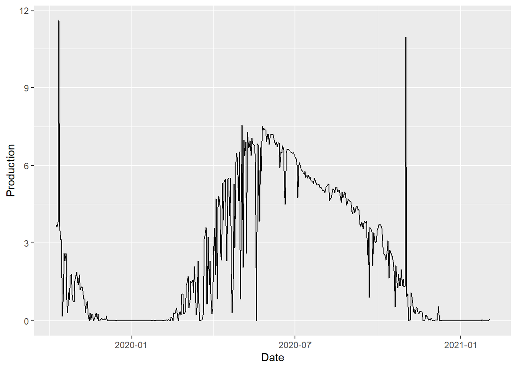

```r
hour = 7
dt_plot = df[Hour == hour]
ggplot(data = dt_plot, aes(x = Date, y = Production)) + geom_line()
```

Including production at time 7 might be reasonable due to the fact it might show an increasing behaviours almost around the days we are trying to forecast as it did last year. As a result in our model assumption, we are going to consider the data between hours 7 and 17, and assign 0 to the rest.

# Analysis and Comparison

```r
dt = df[Hour >= 7 & Hour <= 17 ]

#hour update

model_hour = 10

dt_daily = dt[Hour == model_hour ]

dt_daily
```

```
##            Date Hour Production           timestamp CLOUD_LOW_LAYER_37.75_34.25
##   1: 2019-10-09   10      24.87 2019-10-09 10:00:00                           0
##   2: 2019-10-10   10      24.49 2019-10-10 10:00:00                           0
##   3: 2019-10-11   10      18.90 2019-10-11 10:00:00                           0
##   4: 2019-10-12   10      25.78 2019-10-12 10:00:00                           0
##   5: 2019-10-13   10      25.21 2019-10-13 10:00:00                           0
##  ---
## 479: 2021-01-29   10       5.82 2021-01-29 10:00:00                         100
## 480: 2021-01-30   10      13.00 2021-01-30 10:00:00                           0
## 481: 2021-01-31   10       6.69 2021-01-31 10:00:00                          95
## 482: 2021-02-01   10      22.18 2021-02-01 10:00:00                           0
## 483: 2021-02-02   10      11.98 2021-02-02 10:00:00                           0
##      CLOUD_LOW_LAYER_37.75_34.5 CLOUD_LOW_LAYER_38_34.25
##   1:                          0                        0
##   2:                          0                        0
```

[output cut: 33 more lines]

## METHOD A: FORECASTING WITH TIME SERIES ANALYSIS

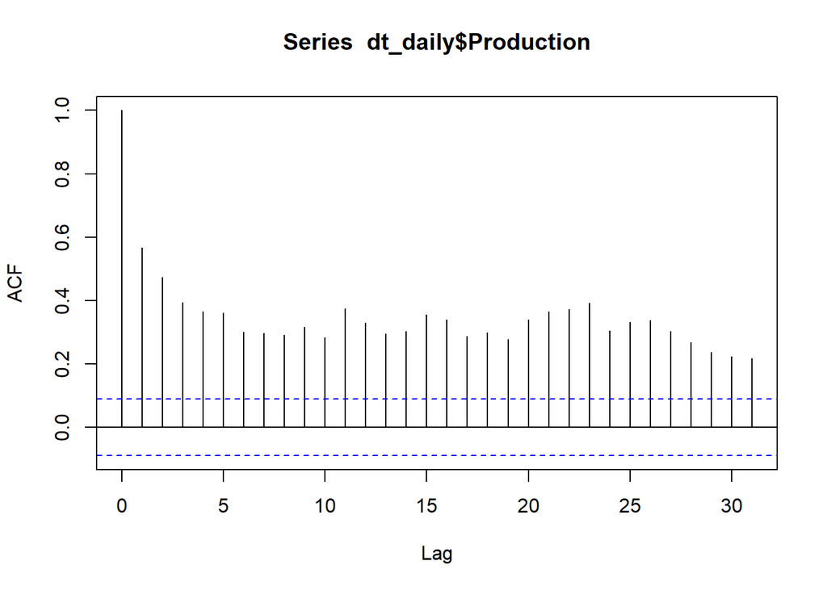

```r
acf(dt_daily$Production, lag.max = 31)
```

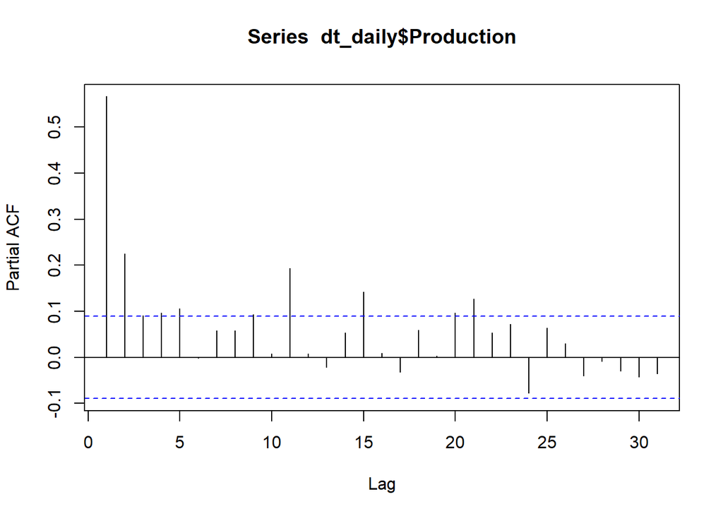

```r
pacf(dt_daily$Production, lag.max = 31)
```

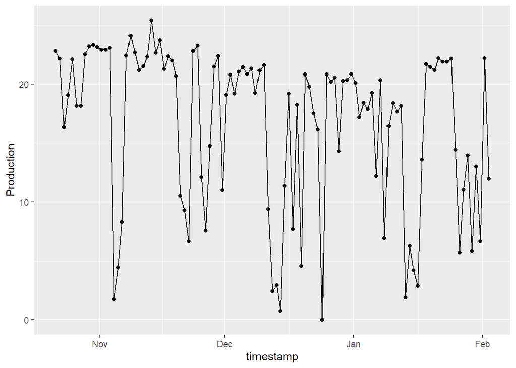

```r
ggplot(data = dt_daily[Date > as.Date('2021-02-02') - 105],
       aes(x = timestamp, y = Production)) + geom_line() + geom_point()
```

Although we cannot really see a seasonality pattern in the 15 week daily plot above, we know that our data consists of daily series so we can choose 7 for the frequency. If we were to work with the first data dt consisting of series at an hourly level could manifest seasonality as it was seen in the two month plot above.

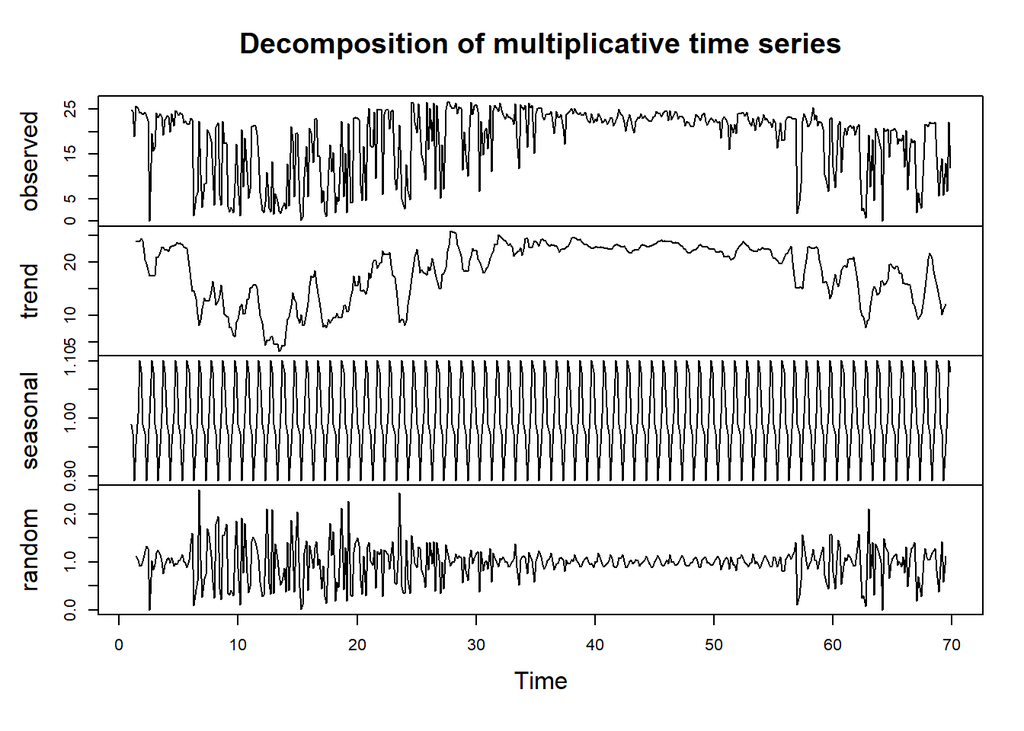

```r
dt_daily_ts = ts(dt_daily$Production, freq = 7)
ts_decomposed = decompose(dt_daily_ts, type = 'multiplicative')
plot(ts_decomposed)
```

Since there are too many variance fluctuations based on time and also there are no transformations made on the series, it would make sense to use multiplicative decomposition. Trend, seasonal and random components can be observed here. It seems like random components do not accord with our white noice assumption that must hold to forecast for time series forecasting. Although mean change might conform stationarity assumption there is too much variance change along the time. Since we cannot really account for those changes in the random component, we can continue with modelling the random part of the story. Let’s first examine autocorrelation and partial autocorrelation functions to have an idea about orders of time series arima model we are going to implement.

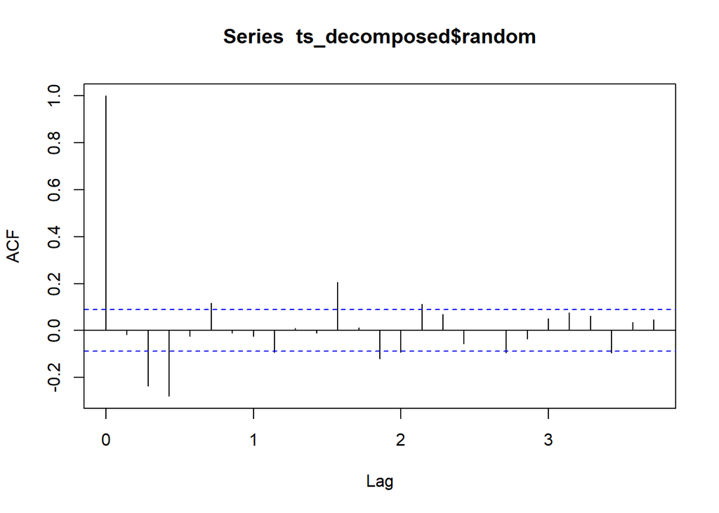

```r
acf(ts_decomposed$random,na.action=na.pass)
```

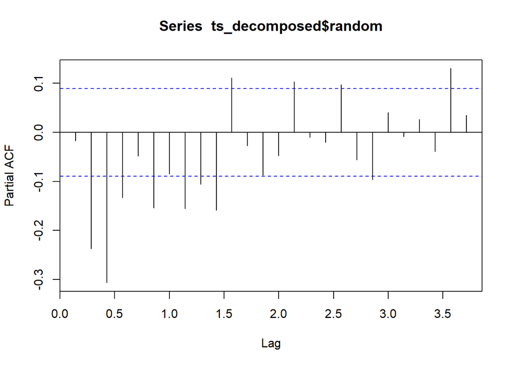

```r
pacf(ts_decomposed$random,na.action=na.pass)
```

```r
auto.arima(ts_decomposed$random, seasonal = TRUE)
```

```
## Series: ts_decomposed$random
## ARIMA(5,0,5) with non-zero mean
##
## Coefficients:
##          ar1     ar2     ar3     ar4      ar5      ma1     ma2      ma3
##       0.2329  0.2531  0.3051  0.4679  -0.3856  -0.4503  -0.519  -0.4961
## s.e.  0.0669  0.0704  0.0769  0.0684   0.0630   0.0447   0.059   0.0642
##           ma4     ma5    mean
##       -0.3364  0.8671  0.9905
## s.e.   0.0546  0.0493  0.0073
##
## sigma^2 estimated as 0.1037:  log likelihood=-132.77
## AIC=289.55   AICc=290.22   BIC=339.56
```

Auto.arima neighbourhood seacrh revealed an order (5,0,5) it is not really easy to decide on the order for some time points.

```r
model_hour = 13
dt_daily = dt[Hour == model_hour]
dt_daily_ts = ts(dt_daily$Production, freq = 7)
ts_decomposed = decompose(dt_daily_ts, type = 'multiplicative')
auto.arima(ts_decomposed$random)
```

```
## Series: ts_decomposed$random
## ARIMA(3,0,2)(1,0,0)[7] with non-zero mean
##
## Coefficients:
##          ar1     ar2      ar3      ma1      ma2     sar1    mean
##       0.0316  0.0199  -0.3492  -0.3304  -0.3806  -0.0579  0.9977
## s.e.  0.1400  0.0939   0.0523   0.1432   0.1344   0.0519  0.0032
##
## sigma^2 estimated as 0.1073:  log likelihood=-141.67
## AIC=299.34   AICc=299.65   BIC=332.68
```

```r
return_day = data.frame(n = as.numeric(rep(0,7)))

for (model_hour in c(7:17)){
  dt_daily = dt[Hour == model_hour & Date <= as.Date('2021-02-02') - 1]
  dt_daily_ts = ts(dt_daily$Production, freq = 7)
  ts_decomposed = decompose(dt_daily_ts, type = 'multiplicative')
  model = auto.arima(ts_decomposed$random)
  trend= tail(ts_decomposed$trend[!is.na(ts_decomposed$trend)],1)
  season= as.numeric(tail(ts_decomposed$seasonal, 1))
  predicted = predict(model, n.ahead = 1)$pred * trend * season
  return_day = rbind(return_day,as.numeric(predicted))
}
return_day = list(append(return_day$n,rep(0,6)))

actual = df[Date == as.Date('2021-02-02'), .(Production)]
actual[,predicted := return_day]
actual[,accu(Production, predicted)]
```

```
##    n       sd     FBias MPE MAPE     RMSE      MAD     WMAPE
## 1 24 8.684576 0.1885874 NaN  NaN 2.738425 1.299295 0.2245002
```

```r
# If we only compared values other than 0

return_day = data.frame(n = as.numeric())

for (model_hour in c(7:17)){
  dt_daily = dt[Hour == model_hour & Date <= as.Date('2021-02-02') - 1]
  dt_daily_ts = ts(dt_daily$Production, freq = 7)
  ts_decomposed = decompose(dt_daily_ts, type = 'multiplicative')
  model = auto.arima(ts_decomposed$random)
  trend= tail(ts_decomposed$trend[!is.na(ts_decomposed$trend)],1)
  season= as.numeric(tail(ts_decomposed$seasonal, 1))
  predicted = predict(model, n.ahead = 1)$pred * trend * season
  return_day = rbind(return_day,as.numeric(predicted))
}
setnames(return_day,'forecast')
actual = dt[Date == as.Date('2021-02-02'), .(Production)]
actual[,predicted := return_day]

actual[,accu(Production,predicted)]
```

```
##    n       sd     FBias       MPE      MAPE     RMSE      MAD     WMAPE
## 1 11 8.858094 0.1885874 0.2524943 0.2806386 4.044922 2.834825 0.2245002
```

```r
# Since it is required to make a forecast for two days later
return_day = data.frame(n1 = as.numeric(), n2 = as.numeric())

for (model_hour in c(7:17)){
  dt_daily = dt[Hour == model_hour & Date <= as.Date('2021-02-02')]
  dt_daily_ts = ts(dt_daily$Production, freq = 7)
  ts_decomposed = decompose(dt_daily_ts, type = 'multiplicative')
  model = auto.arima(ts_decomposed$random)
  trend= tail(ts_decomposed$trend[!is.na(ts_decomposed$trend)],1)
  season= as.numeric(tail(ts_decomposed$seasonal, 2))
  predicted = predict(model, n.ahead = 2)$pred * trend * season
  return_day = rbind(return_day,as.numeric(predicted))
}

return_day[2]
```

```
##    X0.0116162281617721
## 1           0.01161623
## 2           2.17762239
## 3           8.66139462
## 4          12.11846038
## 5          22.26422245
## 6          20.94590554
## 7          19.60538961
## 8          18.48619457
## 9          14.52835428
## 10          5.04204062
## 11          1.46754823
```

## METHOD B: FORECASTING WITH REGRESSION

```r
dt
```

```
##             Date Hour Production           timestamp
##    1: 2019-10-09    7       3.70 2019-10-09 07:00:00
##    2: 2019-10-09    8      11.15 2019-10-09 08:00:00
##    3: 2019-10-09    9      19.81 2019-10-09 09:00:00
##    4: 2019-10-09   10      24.87 2019-10-09 10:00:00
##    5: 2019-10-09   11      25.74 2019-10-09 11:00:00
##   ---
## 5309: 2021-02-02   13      23.24 2021-02-02 13:00:00
## 5310: 2021-02-02   14      22.86 2021-02-02 14:00:00
## 5311: 2021-02-02   15      17.61 2021-02-02 15:00:00
## 5312: 2021-02-02   16       5.32 2021-02-02 16:00:00
## 5313: 2021-02-02   17       1.36 2021-02-02 17:00:00
##       CLOUD_LOW_LAYER_37.75_34.25 CLOUD_LOW_LAYER_37.75_34.5
##    1:                           0                          0
##    2:                           0                          0
```

[output cut: 45 more lines]

In the previous part of our analysis, lagged variables up to 4 was found to be significat in the predetermined interval for a specific hour series. Now, additional trend or seasonal variables might be significant but in the previous examination it was found that trend variable would not really have a significant effect. Even if we could not observed any trend behavior at first, it might have a slight effect due to the global warming.

```r
dt[,month := as.factor(month(Date))]
model_hour = 13
dt_daily = dt[Hour == model_hour & Date <= as.Date('2021-02-02') - 1]
dt_daily[,lag_1 := shift(Production,1)]
dt_daily[,lag_2 := shift(Production,2)]
dt_daily[,lag_3 := shift(Production,3)]
dt_daily[,lag_4 := shift(Production,4)]
dt_daily[,trend := (1:.N)]


fit1=lm( Production ~ month + CLOUD_LOW_LAYER_37.75_34.25 + CLOUD_LOW_LAYER_37.75_34.5
         + CLOUD_LOW_LAYER_38_34.25 + CLOUD_LOW_LAYER_38_34.5 +
           DSWRF_37.75_34.25 + DSWRF_37.75_34.5 + DSWRF_38_34.25 +
           DSWRF_38_34.5 + TEMP_37.75_34.25 + TEMP_37.75_34.5 +
           TEMP_38_34.25 + TEMP_38_34.5 + trend, dt_daily)


summary(fit1)
```

```
##
## Call:
## lm(formula = Production ~ month + CLOUD_LOW_LAYER_37.75_34.25 +
##     CLOUD_LOW_LAYER_37.75_34.5 + CLOUD_LOW_LAYER_38_34.25 + CLOUD_LOW_LAYER_38_34.5 +
##     DSWRF_37.75_34.25 + DSWRF_37.75_34.5 + DSWRF_38_34.25 + DSWRF_38_34.5 +
##     TEMP_37.75_34.25 + TEMP_37.75_34.5 + TEMP_38_34.25 + TEMP_38_34.5 +
##     trend, data = dt_daily)
##
## Residuals:
##      Min       1Q   Median       3Q      Max
## -22.6496  -2.2011   0.5559   2.8605  17.3581
##
## Coefficients:
##                               Estimate Std. Error t value Pr(>|t|)
## (Intercept)                  1.646e+00  2.152e+00   0.765 0.444714
## month2                      -1.694e+00  1.317e+00  -1.286 0.199252
## month3                      -6.402e+00  1.649e+00  -3.882 0.000119 ***
## month4                      -8.542e+00  2.068e+00  -4.130 4.32e-05 ***
## month5                      -1.062e+01  2.541e+00  -4.180 3.50e-05 ***
## month6                      -1.236e+01  2.703e+00  -4.574 6.18e-06 ***
## month7                      -1.248e+01  2.848e+00  -4.381 1.47e-05 ***
## month8                      -1.137e+01  2.682e+00  -4.239 2.72e-05 ***
## month9                      -7.594e+00  2.455e+00  -3.093 0.002102 **
## month10                     -2.408e+00  1.746e+00  -1.379 0.168500
## month11                      1.408e+00  1.204e+00   1.170 0.242593
## month12                      1.728e+00  9.893e-01   1.746 0.081401 .
## CLOUD_LOW_LAYER_37.75_34.25  4.789e-02  4.447e-02   1.077 0.282117
## CLOUD_LOW_LAYER_37.75_34.5  -6.765e-02  4.132e-02  -1.637 0.102270
## CLOUD_LOW_LAYER_38_34.25    -6.122e-02  2.678e-02  -2.287 0.022682 *
## CLOUD_LOW_LAYER_38_34.5      4.153e-02  2.642e-02   1.572 0.116673
## DSWRF_37.75_34.25            2.631e-02  1.187e-02   2.216 0.027193 *
## DSWRF_37.75_34.5            -3.806e-04  9.961e-03  -0.038 0.969534
## DSWRF_38_34.25              -9.556e-03  1.041e-02  -0.918 0.358991
## DSWRF_38_34.5                2.053e-02  9.139e-03   2.247 0.025112 *
## TEMP_37.75_34.25            -2.126e+00  4.669e-01  -4.554 6.75e-06 ***
## TEMP_37.75_34.5              1.440e+00  4.498e-01   3.201 0.001466 **
## TEMP_38_34.25                2.035e+00  6.391e-01   3.184 0.001552 **
## TEMP_38_34.5                -1.354e+00  4.438e-01  -3.050 0.002420 **
## trend                        4.900e-03  1.907e-03   2.570 0.010492 *
## ---
## Signif. codes:  0 '***' 0.001 '**' 0.01 '*' 0.05 '.' 0.1 ' ' 1
##
## Residual standard error: 5.182 on 457 degrees of freedom
## Multiple R-squared:  0.5608, Adjusted R-squared:  0.5377
## F-statistic: 24.31 on 24 and 457 DF,  p-value: < 2.2e-16
```

Without the lagged variables, a model is obtained above with significant temperature values, and monthly information. As we stated, trend has a small effect but it seems significant enough.

```r
fit2=lm( Production ~ month + CLOUD_LOW_LAYER_37.75_34.25 + CLOUD_LOW_LAYER_37.75_34.5
         + CLOUD_LOW_LAYER_38_34.25 + CLOUD_LOW_LAYER_38_34.5 +
           DSWRF_37.75_34.25 + DSWRF_37.75_34.5 + DSWRF_38_34.25 +
           DSWRF_38_34.5 + TEMP_37.75_34.25 + TEMP_37.75_34.5 +
           TEMP_38_34.25 + TEMP_38_34.5 + lag_1 + trend, dt_daily)


summary(fit2)
```

```
##
## Call:
## lm(formula = Production ~ month + CLOUD_LOW_LAYER_37.75_34.25 +
##     CLOUD_LOW_LAYER_37.75_34.5 + CLOUD_LOW_LAYER_38_34.25 + CLOUD_LOW_LAYER_38_34.5 +
##     DSWRF_37.75_34.25 + DSWRF_37.75_34.5 + DSWRF_38_34.25 + DSWRF_38_34.5 +
##     TEMP_37.75_34.25 + TEMP_37.75_34.5 + TEMP_38_34.25 + TEMP_38_34.5 +
##     lag_1 + trend, data = dt_daily)
##
## Residuals:
##      Min       1Q   Median       3Q      Max
## -22.9554  -2.1243   0.6494   2.7644  17.9725
##
## Coefficients:
##                               Estimate Std. Error t value Pr(>|t|)
## (Intercept)                   0.637146   2.172028   0.293 0.769395
## month2                       -1.810772   1.311077  -1.381 0.167916
## month3                       -6.344255   1.641094  -3.866 0.000127 ***
## month4                       -8.429930   2.058198  -4.096 4.98e-05 ***
## month5                      -10.430989   2.528760  -4.125 4.41e-05 ***
## month6                      -12.009250   2.691508  -4.462 1.03e-05 ***
## month7                      -11.909304   2.840790  -4.192 3.32e-05 ***
## month8                      -10.772295   2.676344  -4.025 6.67e-05 ***
## month9                       -7.071194   2.449217  -2.887 0.004073 **
## month10                      -2.315854   1.736676  -1.333 0.183036
## month11                       1.244481   1.199066   1.038 0.299879
## month12                       1.692680   0.983780   1.721 0.086006 .
## CLOUD_LOW_LAYER_37.75_34.25   0.048120   0.044219   1.088 0.277072
## CLOUD_LOW_LAYER_37.75_34.5   -0.073725   0.041155  -1.791 0.073892 .
## CLOUD_LOW_LAYER_38_34.25     -0.053196   0.026792  -1.986 0.047687 *
## CLOUD_LOW_LAYER_38_34.5       0.042513   0.026276   1.618 0.106370
## DSWRF_37.75_34.25             0.025884   0.011809   2.192 0.028891 *
## DSWRF_37.75_34.5             -0.001110   0.009908  -0.112 0.910818
## DSWRF_38_34.25               -0.009419   0.010349  -0.910 0.363220
## DSWRF_38_34.5                 0.021036   0.009088   2.315 0.021077 *
## TEMP_37.75_34.25             -2.062163   0.464852  -4.436 1.15e-05 ***
## TEMP_37.75_34.5               1.397908   0.447966   3.121 0.001920 **
## TEMP_38_34.25                 1.915529   0.637018   3.007 0.002784 **
## TEMP_38_34.5                 -1.299403   0.441876  -2.941 0.003442 **
## lag_1                         0.100068   0.037539   2.666 0.007957 **
## trend                         0.004271   0.001918   2.226 0.026477 *
## ---
## Signif. codes:  0 '***' 0.001 '**' 0.01 '*' 0.05 '.' 0.1 ' ' 1
##
## Residual standard error: 5.153 on 455 degrees of freedom
##   (1 observation deleted due to missingness)
## Multiple R-squared:  0.5671, Adjusted R-squared:  0.5433
## F-statistic: 23.84 on 25 and 455 DF,  p-value: < 2.2e-16
```

If we were to build a model with pca components since most of the variation is explained by the first component

```r
pca_cloud = prcomp(dt_daily[,c(5:8)], center = TRUE,scale. = TRUE)
summary(pca_cloud)
```

```
## Importance of components:
##                           PC1     PC2     PC3     PC4
## Standard deviation     1.9103 0.47855 0.30612 0.16800
## Proportion of Variance 0.9123 0.05725 0.02343 0.00706
## Cumulative Proportion  0.9123 0.96952 0.99294 1.00000
```

```r
pca_DSWRF = prcomp(dt_daily[,c(9:12)], center = TRUE,scale. = TRUE)
summary(pca_DSWRF)
```

```
## Importance of components:
##                           PC1     PC2     PC3     PC4
## Standard deviation     1.9832 0.20340 0.13785 0.08048
## Proportion of Variance 0.9833 0.01034 0.00475 0.00162
## Cumulative Proportion  0.9833 0.99363 0.99838 1.00000
```

```r
pca_temp = prcomp(dt_daily[,c(13:16)], center = TRUE,scale. = TRUE)
summary(pca_temp)
```

```
## Importance of components:
##                           PC1     PC2     PC3     PC4
## Standard deviation     1.9971 0.08773 0.05174 0.03545
## Proportion of Variance 0.9971 0.00192 0.00067 0.00031
## Cumulative Proportion  0.9971 0.99902 0.99969 1.00000
```

```r
dt_daily[,pca_temp := pca_temp$x[,1]]
dt_daily[,pca_DSWRF := pca_DSWRF$x[,1]]
dt_daily[,pca_cloud := pca_cloud$x[,1]]

fit3=lm( Production ~ month + pca_temp + pca_cloud
         + pca_DSWRF + lag_1 + lag_2 +
           lag_3 + lag_4 + trend, dt_daily)
summary(fit3)
```

```
##
## Call:
## lm(formula = Production ~ month + pca_temp + pca_cloud + pca_DSWRF +
##     lag_1 + lag_2 + lag_3 + lag_4 + trend, data = dt_daily)
##
## Residuals:
##      Min       1Q   Median       3Q      Max
## -23.7391  -1.8122   0.7925   2.8464  17.7465
##
## Coefficients:
##               Estimate Std. Error t value Pr(>|t|)
## (Intercept)  21.319077   1.840589  11.583  < 2e-16 ***
## month2       -2.423368   1.300644  -1.863 0.063073 .
## month3       -6.224247   1.631500  -3.815 0.000155 ***
## month4       -9.775140   1.957562  -4.994 8.44e-07 ***
## month5      -12.297086   2.429289  -5.062 6.02e-07 ***
## month6      -13.961702   2.605743  -5.358 1.34e-07 ***
## month7      -14.017944   2.776114  -5.049 6.41e-07 ***
## month8      -12.446641   2.617984  -4.754 2.67e-06 ***
## month9       -8.711982   2.373665  -3.670 0.000271 ***
## month10      -3.263726   1.682776  -1.939 0.053056 .
## month11       0.732673   1.132554   0.647 0.518007
## month12       1.694584   0.979177   1.731 0.084193 .
## pca_temp      0.033987   0.366606   0.093 0.926177
## pca_cloud    -0.544097   0.214898  -2.532 0.011678 *
## pca_DSWRF    -4.326472   0.445454  -9.713  < 2e-16 ***
## lag_1         0.122719   0.038728   3.169 0.001634 **
## lag_2        -0.012836   0.038709  -0.332 0.740344
## lag_3        -0.069728   0.038628  -1.805 0.071712 .
## lag_4         0.064352   0.037788   1.703 0.089254 .
## trend         0.005088   0.001956   2.601 0.009600 **
## ---
## Signif. codes:  0 '***' 0.001 '**' 0.01 '*' 0.05 '.' 0.1 ' ' 1
##
## Residual standard error: 5.256 on 458 degrees of freedom
##   (4 observations deleted due to missingness)
## Multiple R-squared:  0.5457, Adjusted R-squared:  0.5268
## F-statistic: 28.95 on 19 and 458 DF,  p-value: < 2.2e-16
```

```r
pca_temp_lag = shift(pca_temp$x[,1],1)
pca_DSWRF_lag = shift(pca_DSWRF$x[,1],1)
pca_cloud_lag = shift(pca_cloud$x[,1],1)

dt_daily[,pca_temp_lag := pca_temp_lag]
dt_daily[,pca_DSWRF_lag := pca_DSWRF_lag]
dt_daily[,pca_cloud_lag := pca_cloud_lag]

fit4=lm( Production ~ month + pca_temp + pca_cloud
         + pca_DSWRF + lag_1 + lag_2 +
           lag_3 + lag_4 + trend + pca_temp_lag + pca_DSWRF_lag +
           pca_cloud_lag, dt_daily)
summary(fit4)
```

```
##
## Call:
## lm(formula = Production ~ month + pca_temp + pca_cloud + pca_DSWRF +
##     lag_1 + lag_2 + lag_3 + lag_4 + trend + pca_temp_lag + pca_DSWRF_lag +
##     pca_cloud_lag, data = dt_daily)
##
## Residuals:
##      Min       1Q   Median       3Q      Max
## -23.7241  -1.8182   0.7831   2.7444  18.0403
##
## Coefficients:
##                 Estimate Std. Error t value Pr(>|t|)
## (Intercept)    21.582015   2.143693  10.068  < 2e-16 ***
## month2         -2.348932   1.351028  -1.739 0.082777 .
## month3         -6.135075   1.807035  -3.395 0.000746 ***
## month4         -9.712624   2.241660  -4.333 1.81e-05 ***
## month5        -12.204638   2.818037  -4.331 1.83e-05 ***
## month6        -13.890510   3.028032  -4.587 5.81e-06 ***
## month7        -13.918471   3.197260  -4.353 1.66e-05 ***
## month8        -12.341341   2.995402  -4.120 4.50e-05 ***
## month9         -8.591068   2.662459  -3.227 0.001342 **
## month10        -3.175158   1.824672  -1.740 0.082513 .
## month11         0.776286   1.158444   0.670 0.503127
## month12         1.758889   0.992378   1.772 0.076997 .
## pca_temp        0.054012   0.563647   0.096 0.923702
## pca_cloud      -0.525703   0.226336  -2.323 0.020638 *
## pca_DSWRF      -4.348484   0.476928  -9.118  < 2e-16 ***
## lag_1           0.108806   0.047461   2.293 0.022332 *
## lag_2          -0.015778   0.039104  -0.403 0.686788
## lag_3          -0.070145   0.039152  -1.792 0.073859 .
## lag_4           0.064309   0.038091   1.688 0.092041 .
## trend           0.005110   0.001966   2.599 0.009656 **
## pca_temp_lag    0.027673   0.548861   0.050 0.959810
## pca_DSWRF_lag  -0.005635   0.520634  -0.011 0.991369
## pca_cloud_lag  -0.120167   0.227707  -0.528 0.597946
## ---
## Signif. codes:  0 '***' 0.001 '**' 0.01 '*' 0.05 '.' 0.1 ' ' 1
##
## Residual standard error: 5.27 on 455 degrees of freedom
##   (4 observations deleted due to missingness)
## Multiple R-squared:  0.5462, Adjusted R-squared:  0.5242
## F-statistic: 24.89 on 22 and 455 DF,  p-value: < 2.2e-16
```

If we were to build a model with significant variables

```r
fit5=lm( Production ~ month + DSWRF_37.75_34.25 + DSWRF_38_34.5
         + TEMP_37.75_34.25 + TEMP_37.75_34.5 + TEMP_38_34.25 +
           TEMP_38_34.5 + lag_1 + lag_2 +
           lag_3 + lag_4 + trend, dt_daily)

summary(fit5)
```

```
##
## Call:
## lm(formula = Production ~ month + DSWRF_37.75_34.25 + DSWRF_38_34.5 +
##     TEMP_37.75_34.25 + TEMP_37.75_34.5 + TEMP_38_34.25 + TEMP_38_34.5 +
##     lag_1 + lag_2 + lag_3 + lag_4 + trend, data = dt_daily)
##
## Residuals:
##      Min       1Q   Median       3Q      Max
## -23.3357  -2.3014   0.7466   2.6768  17.4772
##
## Coefficients:
##                     Estimate Std. Error t value Pr(>|t|)
## (Intercept)        -3.033058   1.794521  -1.690 0.091679 .
## month2             -2.590055   1.279426  -2.024 0.043514 *
## month3             -8.477597   1.405986  -6.030 3.40e-09 ***
## month4            -11.528656   1.744244  -6.610 1.08e-10 ***
## month5            -14.492276   2.038492  -7.109 4.54e-12 ***
## month6            -16.314013   2.192096  -7.442 4.99e-13 ***
## month7            -16.599267   2.317717  -7.162 3.22e-12 ***
## month8            -15.119519   2.198468  -6.877 2.02e-11 ***
## month9            -10.721460   2.103025  -5.098 5.04e-07 ***
## month10            -4.400967   1.586209  -2.775 0.005756 **
## month11             0.643536   1.193238   0.539 0.589931
## month12             1.688718   0.987412   1.710 0.087902 .
## DSWRF_37.75_34.25   0.027281   0.005799   4.705 3.38e-06 ***
## DSWRF_38_34.5       0.016218   0.004728   3.430 0.000658 ***
## TEMP_37.75_34.25   -1.971418   0.459396  -4.291 2.17e-05 ***
## TEMP_37.75_34.5     1.389990   0.434853   3.196 0.001488 **
## TEMP_38_34.25       1.753272   0.592440   2.959 0.003243 **
## TEMP_38_34.5       -1.138818   0.424366  -2.684 0.007550 **
## lag_1               0.122626   0.038366   3.196 0.001489 **
## lag_2              -0.027721   0.038399  -0.722 0.470708
## lag_3              -0.058619   0.038445  -1.525 0.128020
## lag_4               0.057314   0.037549   1.526 0.127616
## trend               0.004774   0.001974   2.418 0.015989 *
## ---
## Signif. codes:  0 '***' 0.001 '**' 0.01 '*' 0.05 '.' 0.1 ' ' 1
##
## Residual standard error: 5.204 on 455 degrees of freedom
##   (4 observations deleted due to missingness)
## Multiple R-squared:  0.5576, Adjusted R-squared:  0.5362
## F-statistic: 26.06 on 22 and 455 DF,  p-value: < 2.2e-16
```

Fit 2 was the best model so far. We can use those variables to model.

```r
fit_final=lm( Production ~ month + CLOUD_LOW_LAYER_37.75_34.25 + CLOUD_LOW_LAYER_37.75_34.5
         + CLOUD_LOW_LAYER_38_34.25 + CLOUD_LOW_LAYER_38_34.5 +
           DSWRF_37.75_34.25 + DSWRF_37.75_34.5 + DSWRF_38_34.25 +
           DSWRF_38_34.5 + TEMP_37.75_34.25 + TEMP_37.75_34.5 +
           TEMP_38_34.25 + TEMP_38_34.5 + lag_1 + trend, dt_daily)
```

If we were to use lagged residual variable as it is the case in moving average part of arima models

```r
dt_daily[,lag_residual := c(NA,lag(residuals(fit_final),1))]

fit_final_1 = lm( Production ~ month + CLOUD_LOW_LAYER_37.75_34.25 + CLOUD_LOW_LAYER_37.75_34.5
              + CLOUD_LOW_LAYER_38_34.25 + CLOUD_LOW_LAYER_38_34.5 +
                DSWRF_37.75_34.25 + DSWRF_37.75_34.5 + DSWRF_38_34.25 +
                DSWRF_38_34.5 + TEMP_37.75_34.25 + TEMP_37.75_34.5 +
                TEMP_38_34.25 + TEMP_38_34.5 + lag_1 + lag_residual + trend, dt_daily)
summary(fit_final_1)
```

```
##
## Call:
## lm(formula = Production ~ month + CLOUD_LOW_LAYER_37.75_34.25 +
##     CLOUD_LOW_LAYER_37.75_34.5 + CLOUD_LOW_LAYER_38_34.25 + CLOUD_LOW_LAYER_38_34.5 +
##     DSWRF_37.75_34.25 + DSWRF_37.75_34.5 + DSWRF_38_34.25 + DSWRF_38_34.5 +
##     TEMP_37.75_34.25 + TEMP_37.75_34.5 + TEMP_38_34.25 + TEMP_38_34.5 +
##     lag_1 + lag_residual + trend, data = dt_daily)
##
## Residuals:
##        Min         1Q     Median         3Q        Max
## -2.772e-13 -2.053e-15 -1.730e-16  2.186e-15  1.101e-13
##
## Coefficients:
##                               Estimate Std. Error    t value Pr(>|t|)
## (Intercept)                  6.371e-01  6.195e-15  1.028e+14   <2e-16 ***
## month2                      -1.811e+00  3.739e-15 -4.842e+14   <2e-16 ***
## month3                      -6.344e+00  4.681e-15 -1.355e+15   <2e-16 ***
## month4                      -8.430e+00  5.870e-15 -1.436e+15   <2e-16 ***
## month5                      -1.043e+01  7.213e-15 -1.446e+15   <2e-16 ***
## month6                      -1.201e+01  7.677e-15 -1.564e+15   <2e-16 ***
## month7                      -1.191e+01  8.103e-15 -1.470e+15   <2e-16 ***
## month8                      -1.077e+01  7.633e-15 -1.411e+15   <2e-16 ***
## month9                      -7.071e+00  6.986e-15 -1.012e+15   <2e-16 ***
## month10                     -2.316e+00  4.953e-15 -4.675e+14   <2e-16 ***
## month11                      1.244e+00  3.420e-15  3.639e+14   <2e-16 ***
## month12                      1.693e+00  2.806e-15  6.032e+14   <2e-16 ***
## CLOUD_LOW_LAYER_37.75_34.25  4.812e-02  1.261e-16  3.815e+14   <2e-16 ***
## CLOUD_LOW_LAYER_37.75_34.5  -7.373e-02  1.174e-16 -6.281e+14   <2e-16 ***
## CLOUD_LOW_LAYER_38_34.25    -5.320e-02  7.642e-17 -6.961e+14   <2e-16 ***
## CLOUD_LOW_LAYER_38_34.5      4.251e-02  7.495e-17  5.673e+14   <2e-16 ***
## DSWRF_37.75_34.25            2.588e-02  3.368e-17  7.685e+14   <2e-16 ***
## DSWRF_37.75_34.5            -1.110e-03  2.826e-17 -3.929e+13   <2e-16 ***
## DSWRF_38_34.25              -9.419e-03  2.952e-17 -3.191e+14   <2e-16 ***
## DSWRF_38_34.5                2.104e-02  2.592e-17  8.115e+14   <2e-16 ***
## TEMP_37.75_34.25            -2.062e+00  1.326e-15 -1.555e+15   <2e-16 ***
## TEMP_37.75_34.5              1.398e+00  1.278e-15  1.094e+15   <2e-16 ***
## TEMP_38_34.25                1.916e+00  1.817e-15  1.054e+15   <2e-16 ***
## TEMP_38_34.5                -1.299e+00  1.260e-15 -1.031e+15   <2e-16 ***
## lag_1                        1.001e-01  1.071e-16  9.346e+14   <2e-16 ***
## lag_residual                 1.000e+00  1.337e-16  7.479e+15   <2e-16 ***
## trend                        4.271e-03  5.472e-18  7.806e+14   <2e-16 ***
## ---
## Signif. codes:  0 '***' 0.001 '**' 0.01 '*' 0.05 '.' 0.1 ' ' 1
##
## Residual standard error: 1.47e-14 on 454 degrees of freedom
##   (1 observation deleted due to missingness)
## Multiple R-squared:      1,  Adjusted R-squared:      1
## F-statistic: 4.969e+30 on 26 and 454 DF,  p-value: < 2.2e-16
```

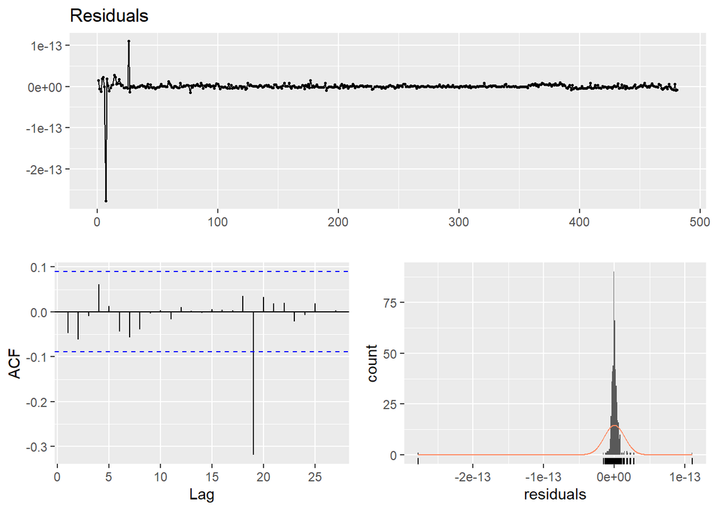

```r
checkresiduals(residuals(fit_final_1))
```

It is highly likely that model above is overfitting to the taraining period, we can compare results on the test day. What is more, residual analysis shows that we have a significant lag at 19 and residuals are so small that they cannot show a normally distributed behavior.

```r
return_day = data.frame(n1 = as.numeric())

for (model_hour in c(7:17)){
  dt_daily = dt[Hour == model_hour & Date <= as.Date('2021-02-02') - 1]
  fit_day = dt[Hour == model_hour & Date == as.Date('2021-02-02')]
  ##### model generation
  dt_daily[,lag_1 := shift(Production,1)]
  fit_day[,lag_1 := tail(dt_daily$Production,1)]

  dt_daily[,trend := (1:.N)]

  fit_final=lm( Production ~ month + CLOUD_LOW_LAYER_37.75_34.25 + CLOUD_LOW_LAYER_37.75_34.5
                + CLOUD_LOW_LAYER_38_34.25 + CLOUD_LOW_LAYER_38_34.5 +
                  DSWRF_37.75_34.25 + DSWRF_37.75_34.5 + DSWRF_38_34.25 +
                  DSWRF_38_34.5 + TEMP_37.75_34.25 + TEMP_37.75_34.5 +
                  TEMP_38_34.25 + TEMP_38_34.5 + lag_1 + trend, dt_daily)

  dt_daily[,lag_residual := c(NA,lag(residuals(fit_final),1))]
  fit_day[,lag_residual := tail(residuals(fit_final),1)]

  fit_final_1 = lm( Production ~ month + CLOUD_LOW_LAYER_37.75_34.25 + CLOUD_LOW_LAYER_37.75_34.5
                    + CLOUD_LOW_LAYER_38_34.25 + CLOUD_LOW_LAYER_38_34.5 +
                      DSWRF_37.75_34.25 + DSWRF_37.75_34.5 + DSWRF_38_34.25 +
                      DSWRF_38_34.5 + TEMP_37.75_34.25 + TEMP_37.75_34.5 +
                      TEMP_38_34.25 + TEMP_38_34.5 + lag_1 + lag_residual + trend, dt_daily)


  predicted = as.numeric(predict(fit_final_1, fit_day))
  return_day = rbind(return_day,as.numeric(predicted))
}

actual = dt[Date == as.Date('2021-02-02'), .(Production)]
actual[,predicted := return_day]

actual[,accu(Production,predicted)]
```

```
##    n       sd      FBias        MPE      MAPE     RMSE      MAD     WMAPE
## 1 11 8.858094 -0.2524389 -0.6957359 0.6957359 4.451645 3.187615 0.2524389
```

Overfitting one resulted in a worse than the arima model. What if we fitted a moving average like regression model without lagged Y values

```r
fit_final_2 = lm( Production ~ month + CLOUD_LOW_LAYER_37.75_34.25 + CLOUD_LOW_LAYER_37.75_34.5
                  + CLOUD_LOW_LAYER_38_34.25 + CLOUD_LOW_LAYER_38_34.5 +
                    DSWRF_37.75_34.25 + DSWRF_37.75_34.5 + DSWRF_38_34.25 +
                    DSWRF_38_34.5 + TEMP_37.75_34.25 + TEMP_37.75_34.5 +
                    TEMP_38_34.25 + TEMP_38_34.5 + lag_residual + trend, dt_daily)
summary(fit_final_2)
```

```
##
## Call:
## lm(formula = Production ~ month + CLOUD_LOW_LAYER_37.75_34.25 +
##     CLOUD_LOW_LAYER_37.75_34.5 + CLOUD_LOW_LAYER_38_34.25 + CLOUD_LOW_LAYER_38_34.5 +
##     DSWRF_37.75_34.25 + DSWRF_37.75_34.5 + DSWRF_38_34.25 + DSWRF_38_34.5 +
##     TEMP_37.75_34.25 + TEMP_37.75_34.5 + TEMP_38_34.25 + TEMP_38_34.5 +
##     lag_residual + trend, data = dt_daily)
##
## Residuals:
##      Min       1Q   Median       3Q      Max
## -0.62505 -0.05656 -0.00336  0.06543  1.93661
##
## Coefficients:
##                               Estimate Std. Error t value Pr(>|t|)
## (Intercept)                 -2.592e+00  6.204e-02 -41.779  < 2e-16 ***
## month2                       1.225e+00  4.178e-02  29.315  < 2e-16 ***
## month3                       1.075e-01  4.974e-02   2.161  0.03119 *
## month4                       1.040e+00  5.934e-02  17.526  < 2e-16 ***
## month5                       7.665e-01  7.372e-02  10.397  < 2e-16 ***
## month6                       6.899e-01  7.935e-02   8.695  < 2e-16 ***
## month7                       8.122e-01  8.917e-02   9.108  < 2e-16 ***
## month8                       1.898e+00  8.337e-02  22.766  < 2e-16 ***
## month9                      -7.008e-02  7.352e-02  -0.953  0.34097
## month10                     -7.534e-01  5.166e-02 -14.583  < 2e-16 ***
## month11                     -5.178e-01  3.754e-02 -13.792  < 2e-16 ***
## month12                      4.065e-01  3.198e-02  12.708  < 2e-16 ***
## CLOUD_LOW_LAYER_37.75_34.25 -4.561e-03  7.881e-04  -5.787 1.34e-08 ***
## CLOUD_LOW_LAYER_37.75_34.5   1.127e-02  8.006e-04  14.082  < 2e-16 ***
## CLOUD_LOW_LAYER_38_34.25     2.109e-03  5.340e-04   3.950 9.06e-05 ***
## CLOUD_LOW_LAYER_38_34.5     -2.208e-03  5.546e-04  -3.981 8.00e-05 ***
## DSWRF_37.75_34.25            7.674e-03  2.758e-04  27.826  < 2e-16 ***
## DSWRF_37.75_34.5             1.527e-04  2.658e-04   0.574  0.56599
## DSWRF_38_34.25               3.259e-03  2.230e-04  14.614  < 2e-16 ***
## DSWRF_38_34.5                3.010e-03  1.779e-04  16.919  < 2e-16 ***
## TEMP_37.75_34.25            -3.267e-01  1.614e-02 -20.243  < 2e-16 ***
## TEMP_37.75_34.5              4.742e-01  1.437e-02  33.006  < 2e-16 ***
## TEMP_38_34.25                6.324e-02  1.927e-02   3.282  0.00111 **
## TEMP_38_34.5                -1.774e-01  1.405e-02 -12.625  < 2e-16 ***
## lag_residual                 1.000e+00  3.406e-03 293.572  < 2e-16 ***
## trend                        4.231e-04  5.982e-05   7.073 5.75e-12 ***
## ---
## Signif. codes:  0 '***' 0.001 '**' 0.01 '*' 0.05 '.' 0.1 ' ' 1
##
## Residual standard error: 0.1665 on 455 degrees of freedom
##   (1 observation deleted due to missingness)
## Multiple R-squared:  0.9985, Adjusted R-squared:  0.9984
## F-statistic: 1.237e+04 on 25 and 455 DF,  p-value: < 2.2e-16
```

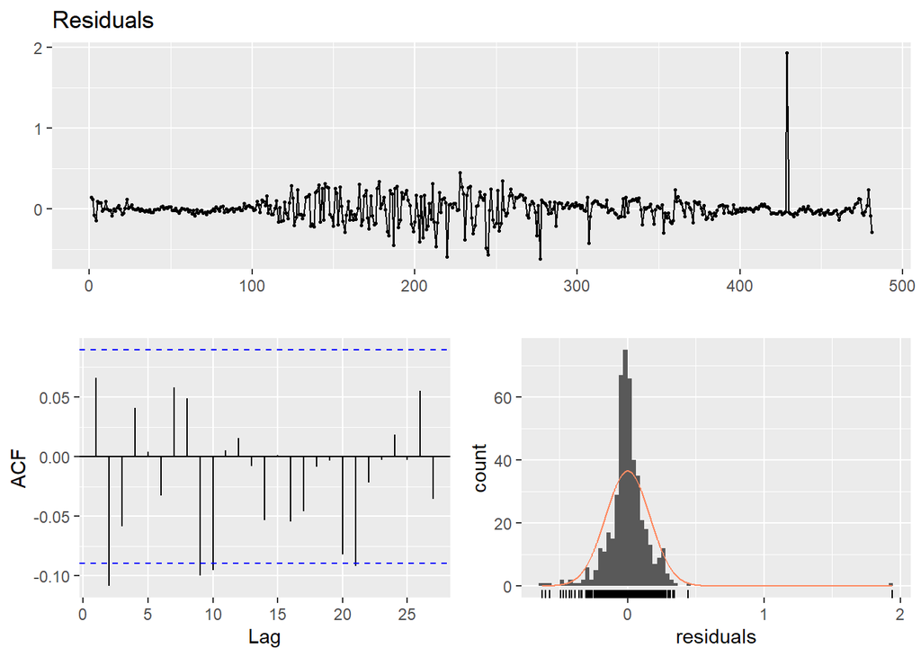

```r
checkresiduals(residuals(fit_final_2))
```

Moving average like regression model gave better results. Even though we can still observe high variance changes with respect to time and outlier, we cannot really deal with those issues because of the nature of the data.

```r
return_day = data.frame(n1 = as.numeric())

for (model_hour in c(7:17)){
  dt_daily = dt[Hour == model_hour & Date <= as.Date('2021-02-02') - 1]
  fit_day = dt[Hour == model_hour & Date == as.Date('2021-02-02')]
  ##### model generation
  dt_daily[,lag_1 := shift(Production,1)]
  fit_day[,lag_1 := tail(dt_daily$Production,1)]

  dt_daily[,trend := (1:.N)]

  fit_final=lm( Production ~ month + CLOUD_LOW_LAYER_37.75_34.25 + CLOUD_LOW_LAYER_37.75_34.5
                + CLOUD_LOW_LAYER_38_34.25 + CLOUD_LOW_LAYER_38_34.5 +
                  DSWRF_37.75_34.25 + DSWRF_37.75_34.5 + DSWRF_38_34.25 +
                  DSWRF_38_34.5 + TEMP_37.75_34.25 + TEMP_37.75_34.5 +
                  TEMP_38_34.25 + TEMP_38_34.5 + lag_1 + trend, dt_daily)

  dt_daily[,lag_residual := c(NA,lag(residuals(fit_final),1))]
  fit_day[,lag_residual := tail(residuals(fit_final),1)]

  fit_final_2 = lm( Production ~ month + CLOUD_LOW_LAYER_37.75_34.25 + CLOUD_LOW_LAYER_37.75_34.5
                    + CLOUD_LOW_LAYER_38_34.25 + CLOUD_LOW_LAYER_38_34.5 +
                      DSWRF_37.75_34.25 + DSWRF_37.75_34.5 + DSWRF_38_34.25 +
                      DSWRF_38_34.5 + TEMP_37.75_34.25 + TEMP_37.75_34.5 +
                      TEMP_38_34.25 + TEMP_38_34.5 + lag_residual + trend, dt_daily)


  predicted = as.numeric(predict(fit_final_2, fit_day))
  return_day = rbind(return_day,as.numeric(predicted))
}
actual = dt[Date == as.Date('2021-02-02'), .(Production)]
actual[,predicted := return_day]

actual[,accu(Production,predicted)]
```

```
##    n       sd      FBias        MPE      MAPE   RMSE      MAD     WMAPE
## 1 11 8.858094 -0.1924438 -0.7563754 0.7645606 3.8782 2.607904 0.2065295
```

Although WMAPE was improved, our main metric MAPE is worse than the ARIMA results.

## Conclusion

```r
# Since it is required to make a forecast for two days later
return_day = data.frame(n1 = as.numeric(), n2 = as.numeric())

for (model_hour in c(7:17)){
  dt_daily = dt[Hour == model_hour & Date <= as.Date('2021-02-02')]
  dt_daily_ts = ts(dt_daily$Production, freq = 7)
  ts_decomposed = decompose(dt_daily_ts, type = 'multiplicative')
  model = auto.arima(ts_decomposed$random)
  trend= tail(ts_decomposed$trend[!is.na(ts_decomposed$trend)],1)
  season= as.numeric(tail(ts_decomposed$seasonal, 2))
  predicted = predict(model, n.ahead = 2)$pred * trend * season
  return_day = rbind(return_day,as.numeric(predicted))
}

return_day[2]
```

```
##    X0.0116162281617721
## 1           0.01161623
## 2           2.17762239
## 3           8.66139462
## 4          12.11846038
## 5          22.26422245
## 6          20.94590554
## 7          19.60538961
## 8          18.48619457
## 9          14.52835428
## 10          5.04204062
## 11          1.46754823
```

Forecasting solar energy production is not an easy task since there are many indicator variables that cannot be explained well and day light times fluctuate significantly throught the year. In our model assumption, seperate models were built on different hours of every day. Analysis might have been completely different if we were to build a model on an aggregated level. As a result of our analysis, hourly built arima model performed the best.